# Cistrome analysis

Kate Lawrenson, Marcos A. S. Fonseca, Annie Y. Liu, Felipe Segato, et. al.

November, 2019

## Introduction

In the following workflow, we describe the main procedures to analyse the enrichment of differentially expressed genes (DEGs) close to experimentaly peaks, derived from Cistrome, for some interesting Trascription Factor (TF).

```r
library(TxDb.Hsapiens.UCSC.hg19.knownGene)
library(org.Hs.eg.db)
library(GenomicRanges)
```

### Auxiliary functions

The `buildTable` function is used to select all genes close to 50000 bp of a given peak coordinates from all Cistrome peaks file. We used the `distance` function from `Genomic Ranges` package.

```r
buildTable <- function(pTF, pInfo.GR, pDados.RNAseq.GR) {

  max_len = 50000
  table.all.genes = NULL

  for (i in 1: length(info.GR)) {

    dist = distance(pInfo.GR[i], pDados.RNAseq.GR)
    info.gene = NULL

    list = which(dist > 0 & dist <= max_len)

    if (length(list) > 0 ) {
      info = data.frame(tf = pTF, peak=i, distance=dist[list], bin=max_len, gene = pDados.RNAseq.GR$symbol[list])

      info.gene = rbind(info.gene, info)
    }

    table.all.genes = rbind(table.all.genes, info.gene)
  }
  return(table.all.genes)
}
```

The `getRandomGR` function is used to generate random peaks following the same chromosome proportion and size of the original cistrome peaks files.

```r
getRandomGR <- function(gr){
  seqnames <- factor(x = paste0('chr',c(1:22,'X', 'Y')), levels = paste0('chr',c(1:22,'X', 'Y')))
  hg19.len <- read.table(file = 'files/hg19.len')
  hg19.len <- hg19.len[hg19.len$V1 %in% seqnames,]
  hg19.len$V1 <- factor(x = hg19.len$V1, levels = seqnames)
  hg19.len <- hg19.len[order(hg19.len$V1),]

  .seqnames <- factor(as.character(seqnames(gr)), levels = levels(seqnames))
  gr.random <- foreach(i=1:length(seqnames), .combine = c) %do% {
    .n <- sum(.seqnames == seqnames[i])
    .max <- hg19.len$V2[i]
    .start <- round(x = runif(n = .n, min = 1, max = .max), digits = 0)
    .width <- width(gr[.seqnames == seqnames[i]])
    .gr <- GRanges(seqnames = seqnames[i], ranges = IRanges(start = .start, width = .width))
    return(.gr)
  }
  return(gr.random)
}
```

### Part 1

### Data loading

The differentially expressed genes are organized in a data frame. All genes are loaded and only genes up and down regulated are selected in the analysis.

```r
load("RData/scenario-NOSExHGSOC-394-TCGA-all-genes.RData")
table(NOSExHGSOC$STATUS)
```

```
##
##    Down NOT.SIG      Up
##     243   20509     176
```

```r
dados.RNAseq <- NOSExHGSOC[which(NOSExHGSOC$STATUS %in% c("Down","Up")),c(1:584)]
scenario = "OxH"
```

[output not shown]

### Gene genomic annotation

We selected the genomic annotation, regarding chromosome name, start, end coordinates for human hg19 build. After the annation is merged with our differentially expressed genes.

```r
dados.RNAseq <- as.data.frame(dados.RNAseq)

txdb_hg19 <- TxDb.Hsapiens.UCSC.hg19.knownGene
genes <- genes(txdb_hg19)
symbols <- unlist(mapIds(org.Hs.eg.db, genes$gene_id, "SYMBOL", "ENTREZID", multiVals = "first"))
genes <- as.data.frame(genes)
genes$symbol <- as.matrix(symbols)
genes <- genes[!(duplicated(genes$symbol)),]
head(genes)

dados.RNAseq <- merge(genes,dados.RNAseq, by.x="symbol",by.y="row.names")
```

[output not shown]

Convert gene annotation into a Genomic Ranges object `dados.RNAseq.GR`.

```r
dados.RNAseq.GR <- makeGRangesFromDataFrame(dados.RNAseq[,1:7],TRUE)
```

### Part 2

Define the number of interaction for random peaks.

```r
ninter = 10
all.rd.c.T = NULL
```

### Part 3

In this step we can select a cistrome peaks file for a given TF. We filter out non-canonical chromosomes. The information are converted to `Genomic Ranges` object.

```r
TF = "ASCL2"

cistrome.info <- read.delim("cistrome/all.ASCL2.peaks.bed", comment.char = "#", header = F)
colnames(cistrome.info) <- c("chr", "start", "end", "name", "score")
cistrome.info <- cistrome.info[which(cistrome.info$chr %in% c("chr1", "chr2", "chr3", "chr4", "chr5", "chr6", "chr7", "chr8", "chr9", "chr10", "chr11", "chr12", "chr13", "chr14", "chr15", "chr16", "chr17", "chr18", "chr19", "chr20", "chr21", "chr22", "chrX", "chrY")),]
cistrome.info <- droplevels(cistrome.info)
cistrome.info$width <- cistrome.info$end - cistrome.info$start

info.GR <- makeGRangesFromDataFrame(cistrome.info, ignore.strand=TRUE)
```

The steps bellow call both auxiliary function.

```r
table.TF = buildTable(TF, info.GR, dados.RNAseq.GR)
if (is.null(table.TF)) {
  table.TF = data.frame(TF=TF, Cistrome=0)
}

for (inter in 1: ninter) {
  #print(paste0("Interaction: ", inter))
  rd.peaks = getRandomGR(info.GR)
  temp_rd = buildTable(TF, rd.peaks, dados.RNAseq.GR)

  if (!is.null(temp_rd)) {
    all.rd.c.T = rbind(all.rd.c.T, data.frame(Var1=TF, Freq=dim(temp_rd)[1]))
  }else {
    all.rd.c.T = rbind(all.rd.c.T, data.frame(Var1=TF, Freq=0))
  }
}

all.rd.c.T$Source = "Random"
head(all.rd.c.T)
```

```
##    Var1 Freq Source
## 1 ASCL2   65 Random
## 2 ASCL2   84 Random
## 3 ASCL2   76 Random
## 4 ASCL2   80 Random
## 5 ASCL2   49 Random
## 6 ASCL2   67 Random
```

```r
head(table.TF)
```

```
##      tf peak distance   bin    gene
## 1 ASCL2    7    22135 50000 TMEM88B
## 2 ASCL2   94    29372 50000  ZNF683
## 3 ASCL2   95    49566 50000  ZNF683
## 4 ASCL2  106    34221 50000    IFI6
## 5 ASCL2  107     6779 50000    IFI6
## 6 ASCL2  126    34188 50000  ZBTB8B
```

```r
counts.TF <- as.data.frame(table(table.TF$tf))
counts.TF$Source = "Cistrome"

table.all <- rbind(counts.TF, all.rd.c.T)
colnames(table.all) <- c("TF", "Freq", "Source")

head(table.all)
```

```
##      TF Freq   Source
## 1 ASCL2  128 Cistrome
## 2 ASCL2   65   Random
## 3 ASCL2   84   Random
## 4 ASCL2   76   Random
## 5 ASCL2   80   Random
## 6 ASCL2   49   Random
```

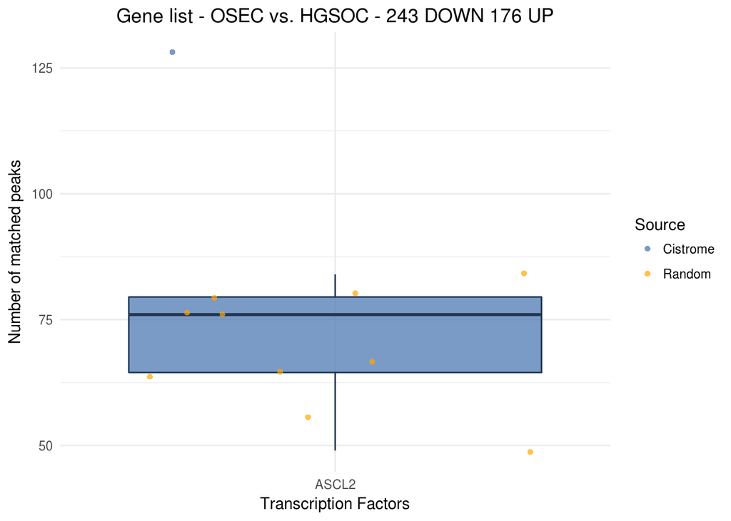

```r
fill <- "#4271AE"
line <- "#1F3552"

p <- ggplot(table.all, aes(x=TF, y=Freq)) +
  ggtitle(paste0("Gene list - OSEC vs. HGSOC - 243 DOWN 176 UP"))+xlab("Transcription Factors")+ylab("Number of matched peaks") +
  geom_boxplot(outlier.shape = NA, fill = fill, colour = line, alpha = 0.7) +
  scale_color_manual(values=c("#4271AE", "orange")) +
  geom_jitter(shape=16, alpha=0.7, aes(colour=Source)) +
  theme_minimal() +
  theme(plot.title = element_text(hjust = 0.5))
p
```

### Conslusion

We demonstrated how to analyse the enrichment of DEG close to TF using Cistrome data. The same procedures can be now applied to other DEG scenarios or different TFs by changuing Part 1 and Part 3. To increase the number of random interaction change Part 2.